# Fertility and Infant Mortality Analysis: 2015 Global Patterns

Lancinet KEITA

2025-09-10

## 0.1 Introduction

This report analyzes the relationship between fertility rates (children per woman) and infant mortality rates (deaths per 1000 births) across countries in 2015. We examine global patterns through world maps and explore the correlation between these two important demographic indicators.

## 0.2 World Map Visualizations

Let’s create world maps to visualize the global distribution of both indicators in 2015.

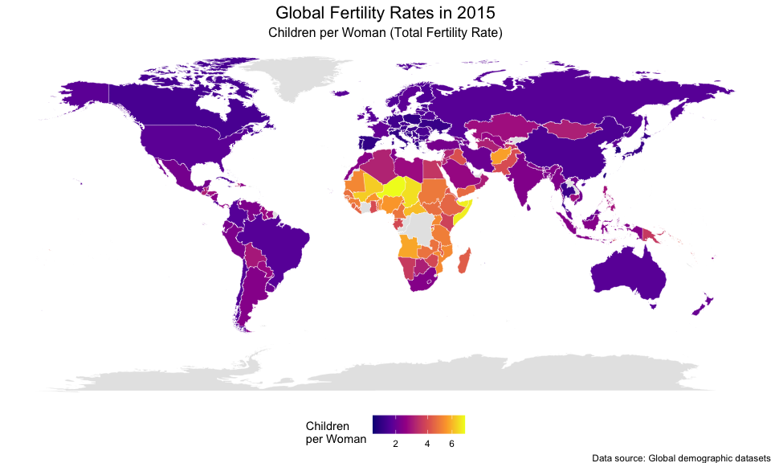

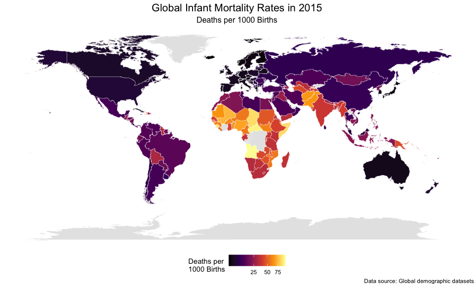

## 0.3 Relationship Analysis

Now let’s examine the relationship between fertility rates and infant mortality rates through a scatterplot and correlation analysis.

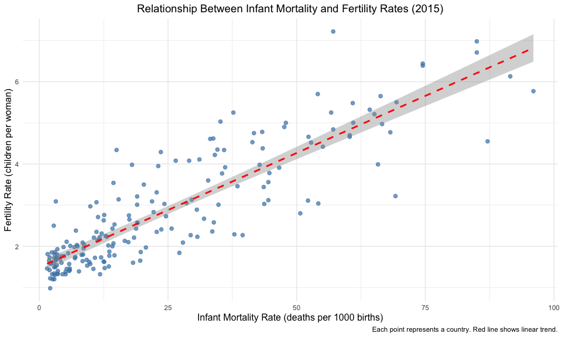

```
## Correlation coefficient between infant mortality and fertility rates: 0.873
```

## 0.4 Interpretation

The analysis reveals several important patterns in the relationship between fertility rates and infant mortality rates in 2015:

### 0.4.1 Key Findings:

1. **Strong Positive Correlation**: There is a strong positive correlation (r = 0.873) between infant mortality rates and fertility rates. This means that countries with higher infant mortality rates tend to have higher fertility rates.
2. **Global Patterns**:
   - Countries in sub-Saharan Africa show both the highest fertility rates and highest infant mortality rates
   - Developed countries in Europe, North America, and parts of Asia show both low fertility and low infant mortality
   - This pattern suggests a demographic transition where improvements in child survival are associated with lower fertility
3. **Demographic Transition Theory**: The relationship supports the demographic transition theory, which posits that as countries develop economically and improve healthcare, both infant mortality and fertility rates decline. Countries at different stages of this transition show varying combinations of these indicators.
4. **Policy Implications**: The strong correlation suggests that efforts to reduce infant mortality through improved healthcare, nutrition, and sanitation may also contribute to fertility decline, which can have important implications for population growth and development planning.

### 0.4.2 Limitations:

- The analysis is cross-sectional (2015 only) and doesn’t capture temporal changes
- Some countries may have missing data for either indicator
- The relationship may be influenced by other factors not included in this analysis

This analysis provides valuable insights into global demographic patterns and the interconnected nature of fertility and child survival indicators.

## 0.5 Reflection on My First Experience with Cursor

The first challenge was figuring out how to find the right data to analyze with two relevant indicators. Another difficulty was that modifying the code directly in Cursor was almost impossible for me. However, I found Cursor very fast in generating code based on instructions, and surprisingly accurate in its responses. This was impressive to me, and I also discovered a new tool that will be very useful for my future work.